Skip to content

# 02-VIM

## [Material](https://www.freecodecamp.org/news/vim-beginners-guide/)

## What's Vim?

Vim is an acronym for `Vi IMproved`. It is a free and open-source **cross-platform text editor**.

## How to Install Vim

- Vim comes pre-installed on most *nix operating systems. But if it's not installed on your system, you can install it with a package manager of your choice.
- Here's the installation command for based operating systems:

  ```
  sudo apt-get update
  sudo apt-get install vim
  ```

- To ensure that it's installed properly, run `which vim` and you should get `/usr/bin/vim` in your output.

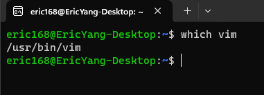

## Get Started with Vim

- enter `vim` into the editor

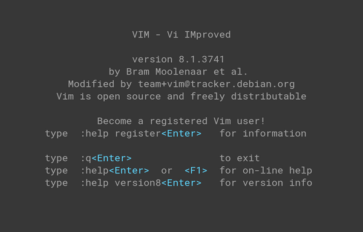

### Vim Modes

There are many modes in Vim. But, we'll be looking at the 4 most important modes.

1. Command Mode
   - This is the **default mode** (also called Normal mode) in `Vim`.
   - Basically, to switch from one mode to another, you have to come to Command Mode first and then navigate to the other mode.
   - The commands that you run without any prefix (colon) indicate that you're running the command in command mode.
2. Command-Line Mode
   - You can use this mode to play around with some commands.
   - commands in this mode are prefixed with a colon (`:`).
   - You can switch to this mode by pressing `: (colon)` in `command mode`.
3. Insert Mode
   - This mode is used to edit the contents of the file.
   - You can switch to insert mode by pressing `i` from `command mode`.
   - You can use the `Esc` key to switch back to `command mode`
4. Visual Mode
   - You can switch to this mode by pressing `v` from the `command mode`.

### Common Operations in Vim

#### Create a New File

1. run `vim` to get into Vim
2. run `:edit sample.txt` to create a new file

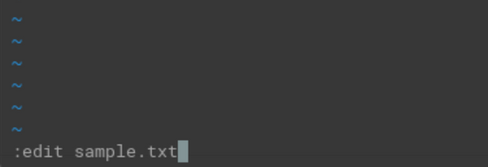

3. After running that command, you'll be in `command mode`

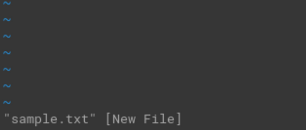

4. To add some text to the created file, press `i` to `insert mode`
   - In this mode, you can type whatever you want into the file.

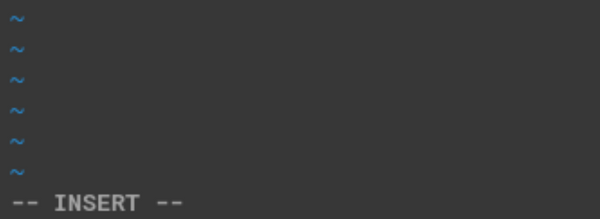

#### Save a File

1. To save a file, you have to switch from Insert mode to Command Line mode.
   - To switch to Command mode from Insert mode, you have to press the `Esc` key.

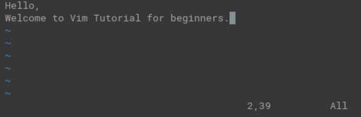

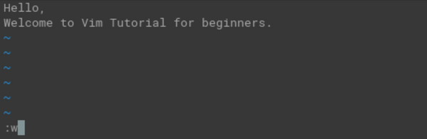

#### Exit Vim

- The proper way to close the file and the Vim editor is by using the command: `:q`

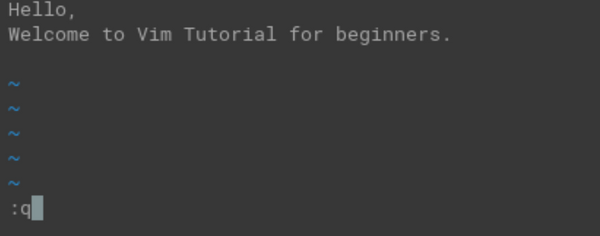

- Alternatively, you can use a command that's the combination of the above 2 commands (**save & quit**) to quickly save and quit Vim. `:wq`

#### Edit a File in Vim

- To edit a file, you have to open the file using Vim and switch to Insert mode.
1. Let's open the sample.txt file using `vim sample.txt`
2. pressing `i` from the Command mode will switch to Insert mode.
3. Type anything you want
4. Press `Esc` on the keyboard and type `:w` to save the file and `:q` to quit Vim.

#### Close the file without saving the changes

- To close the file without saving the changes, you have to run :`q!` from Command mode.

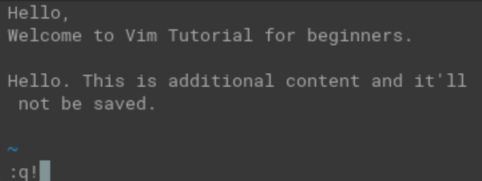

## Cut, Copy, and Paste Text from a File using Vim

1. Enter Visual mode by pressing the `v` key on the keyboard.

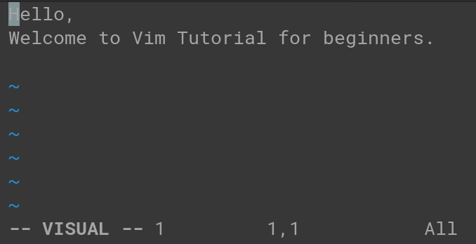

2. Move your cursor, Visual mode highlights the text from the beginning up to your cursor.

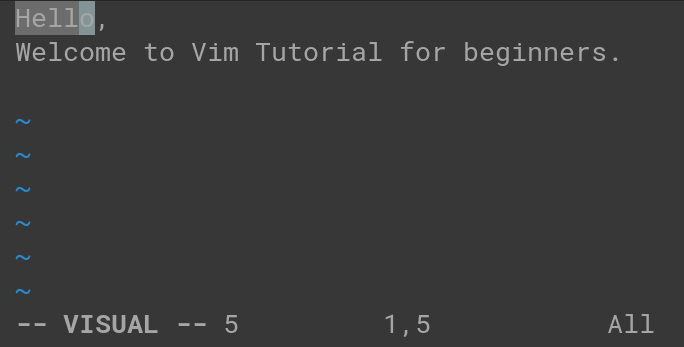

3. hit `y` to **copy** the text or hit `d` to **cut** the text.
4. Move the cursor to the place where you want to paste the text.
5. Press `p (in lowercase)` to paste the text after the cursor and `P (in uppercase)` to paste the text before the cursor.

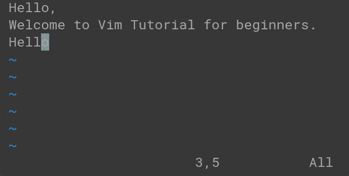

6. Press `:wq` to save and close the file

### Other useful shortcut

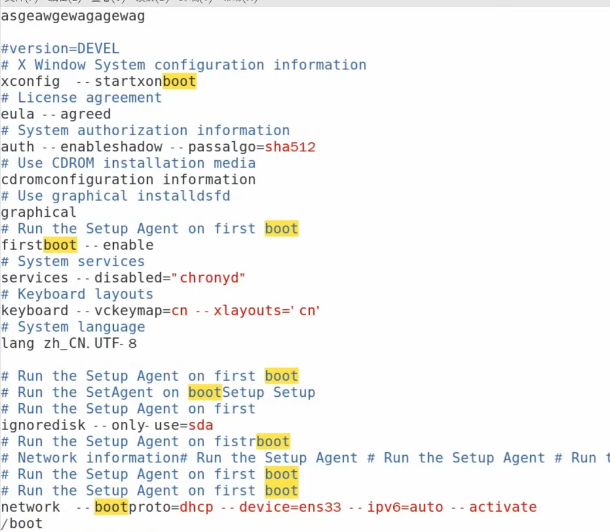

## Vim Shortcut cheating sheet

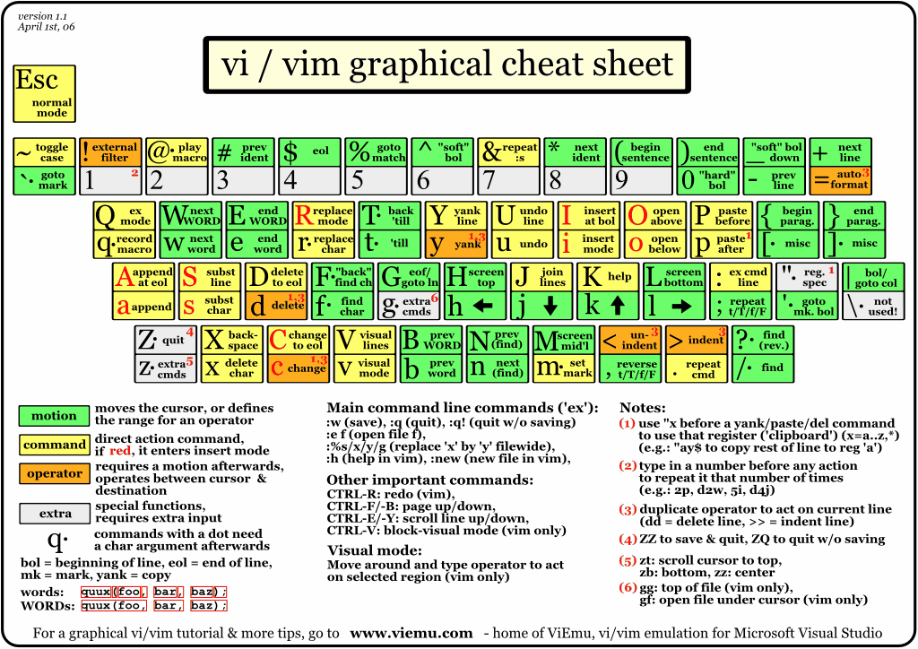

2025-09-18 2025-09-18